# How to estimate local recombination rates with the Marey map method

The `EasyMareyMap` package for R has been implemented to estimate recombination maps from genetic maps (or linkage maps) using the Marey map approach (Rezvoy et al. 2007). The original MareyMap package was designed for interactive graphical use only and does not provide scripting capabilities. It does not allow to process many maps at a time. See the original MareyMap package here [Rezvoy et al. 2007](https://academic.oup.com/bioinformatics/article-lookup/doi/10.1093/bioinformatics/btm315) and [Siberchicot et al. 2017](https://CRAN.R-project.org/package=MareyMap).

Our `EasyMareyMap` package is designed to provide easy access to the data (stored in slots within objects) and the functions via the command line, hence a more machine-friendly approach, in order to maximize scriptability, reproducibility and scalability to large datasets. It offers a statistical framework to estimate recombination maps with the automatic calibration of hyperparameters and a bootstrap procedure to measure the uncertainty of our estimates. The method has been used and validated in (Brazier and Glémin 2022).

Moreover, it offers a statistical framework to estimate recombination maps with the automatic calibration of hyperparameters and a bootstrap procedure to measure the uncertainty of our estimates, which is an advantage for robust data analyses. The method has been used and validated in (Brazier and Glémin 2022). Our `EasyMareyMap` package adds these new features:

- automatic calibration of the smoothing parameter
- bootstraps to estimate a 95% confidence interval
- graphical zone selection to exclude a bunch of outlier markers
- a graphical and statistical framework for comparative genomics (compare Marey maps between species, populations or genomes)

# Installation

```r
# Install BioConductor dependency
BiocManager::install("GenomicRanges")

devtools::install_github("https://github.com/ThomasBrazier/EasyMareyMap")
# or alternatively
install.packages("EasyMareyMap", repos="https://github.com/ThomasBrazier/EasyMareyMap")
```

Now load the package and `ggplot2`.

```r
library(EasyMareyMap)
library(ggplot2)
```

Two S3 objects are at the core of the package: * the `marey_map` object contains all the data and metadata associated with a single map. It contains slots with the Marey map, the recombination map (after estimating it), and additional metadata, such as model goodness of fit. * the `comparative_marey_map` object is a collection of `marey_map` objects over which you can apply `EasyMareyMap` functions or iterate with your custom function. Hence it is a convenient object for manipulating, computing and comparing mutliple maps (i.e. multiple chromosomes and/or datasets).

`EasyMareyMap` functions allow you to: * estimate the recombination map from the Marey map, using loess or smooth spline regression * estimate a bootstrapped confidence interval for recombination rates * predict genetic positions for a new set of markers * plot one or many Marey maps, plot one or many recombination maps * compute chromosome wide summary statistics (mean, median, variance, gini index, periphery-bias ratio…) * comparative plots (lorenz curve, broken stick, see below for details) * apply some corrections to a raw Marey map (e.g. outlier removal)

# Create a `marey_map` object

You can then create a `marey_map` object. It must contain a single map (i.e. one chromosome). We will see later how to treat multiple maps in a convenient way.

```r
m = read.table("../inst/extdata/Arabidopsis_thaliana.txt",
               header = T,
               sep = "\t")
# Column names of the input Marey map
colnames(m)
```

```
#> [1] "set"  "map"  "mkr"  "phys" "gen"  "vld"
```

```r
head(m)
```

```
#>                              set map        mkr   phys  gen  vld
#> 1 Arabidopsis_thaliana_Serin2017   1 RSM_1_0.05  50000 0.00 TRUE
#> 2 Arabidopsis_thaliana_Serin2017   1 RSM_1_0.15 150000 0.31 TRUE
#> 3 Arabidopsis_thaliana_Serin2017   1 RSM_1_0.25 250000 0.63 TRUE
#> 4 Arabidopsis_thaliana_Serin2017   1 RSM_1_0.35 350000 1.28 TRUE
#> 5 Arabidopsis_thaliana_Serin2017   1 RSM_1_0.45 450000 1.92 TRUE
#> 6 Arabidopsis_thaliana_Serin2017   1 RSM_1_0.55 550000 2.24 TRUE
```

```r
# The marey map is imported into a 'marey_map' object
m = m[which(m$map == "1"),]
marey = marey_map(m)
# names of slots in the 'marey_map' object
names(marey)
```

```
#>  [1] "mareyMap"               "recMap"                 "mareyCI"
#>  [4] "chromosomeName"         "chromosomeLength"       "linkageMapLength"
#>  [7] "interpolationMethod"    "model"                  "fitted"
#> [10] "residuals"              "goodness.r.squared"     "goodness.adj.r.squared"
#> [13] "goodness.p"             "windows"                "smoothingParam"
#> [16] "nBootstrap"
```

```r
# See details in ?marey_map
colnames(marey$marey_map)
```

[output not shown]

```r
colnames(marey$recMap)
```

```
#> [1] "set"          "map"          "start"        "end"          "recRate"
#> [6] "lowerRecRate" "upperRecRate"
```

```r
colnames(marey$mareyCI)
```

```
#> [1] "set"                    "map"                    "physicalPosition"
#> [4] "geneticPositioncM"      "upperGeneticPositioncM" "lowerGeneticPositioncM"
```

The `EasyMareyMap` package provides many functions to directly access data or compute summary statistics directly. Moreover, to allow further development and implementation of new features, data and metadata are stored in the `marey_map` object and easily accessible.

The `marey_map` object is a S3 class object (see [S3 class](https://adv-r.hadley.nz/s3.html)). It contains a list of slots: - `mareyMap` stores the input Marey map, in the format specified above. - `recMap` stores the estimated recombination map (cM/Mb), with confidence intervals estimated by bootstrap. - `mareyCI` stores estimated genetic positions of the same genomic windows as the recombination map, instead of recombination rates, with confidence intervals estimated by bootstrap. It can be a good practice to compare genetic positions interpolated in `mareyCI` with genetic positions observed in `mareyMap` to evaluate the quality of the interpolation method. - then a list of attributes of the Marey map and recombination map (e.g. chromosome name and length, interpolation method…). It is important to note that the interpolation model is stored in the `model` slot and all its attributes can be accessed.

There is a function to display a `summary` of a `marey_map` object.

```r
summary(marey)
```

```
#> ===================== Summary of the Marey map ==================
#>  Dataset:  Arabidopsis_thaliana_Serin2017
#>  Chromosome name:  1
#>  Chromosome length (Mb):  30.45
#>  Linkage map length (cM):  117.87
#>  Number of markers:  275
#>  Markers density (marker/Mb):  9.031199
#>  =========================== Recombination map ===================
#>  Recombination rates (cM/Mb):
#>  Min.   1st Qu.    Median      Mean   3rd Qu.      Max.
#> ======================== Interpolation ==========================
#> Interpolation method:
#>  Smoothing parameter:
#>  Number of windows:  0
#>  Number of bootstraps:
#> ================= Goodness of fit (fitted ~ y) ===================
#>  fitted ~ y R squared:
#>  fitted ~ y adjusted R squared:
#>  fitted ~ y p-value
#>  ==================================================================
```

# Manipulate a Marey map

The quality of the input data (the Marey map) is crucial for the performance of the Marey map interpolation function. The input data must be checked carefully before interpolation, and ambiguous markers and errors must be removed or corrected.

The `EasyMareyMap` package provides user-friendly functions to evaluate data quality and correct the most frequent errors. You can also look the `mapFuser` package for similar procedures and more features such as consensus maps (Muijen et al. 2017).

Maps with a low quality often show outlying markers that will strongly negatively affect the performance of interpolation. Outlying markers are mapped outside the global trend of the Marey map. In the figure below, I add some outlier markers to the Marey map around the position 17Mb, just to learn how to remove them. There is a function to `plot` the Marey map of a `marey_map` object. Markers kept for further interpolation are in blue. Markers discarded are in red.

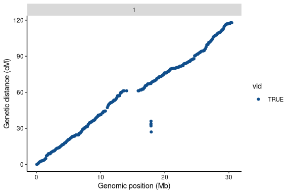

Add random outliers in the Marey map.

```r
marey_outliers = marey

tmp = marey_outliers$mareyMap

d = data.frame(set = unique(tmp$set),
               map = unique(tmp$map),
               mkr = "outlier",
               phys = c(17855000, 17853000, 17858000, 17840000, 17890000),
               gen = c(34, 32, 36, 33, 27),
               vld = TRUE,
               predict.se = NA)
tmp = rbind(tmp, d)
marey_outliers$mareyMap = tmp
rm(tmp)

plot(marey_outliers)
```

## Visual outlier selection

It is possible to perform outlier selection in a visual mode. You just need to draw a region around markers to remove. Left-click to place points of the polygon, then press the `ESC` key or right-click to close the region and return to the script. All markers selected are automatically marked as removed (`vld = FALSE`).

```r
marey = outlier_selection(marey)
```

## Mask genomic regions

Markers can be masked (unmasked) in genomic intervals with the `mask.interval` function (`unmask.interval` respectively). Fo example, you might want to mask regions where markers are difficult to map or have higher sequencing/calling error.

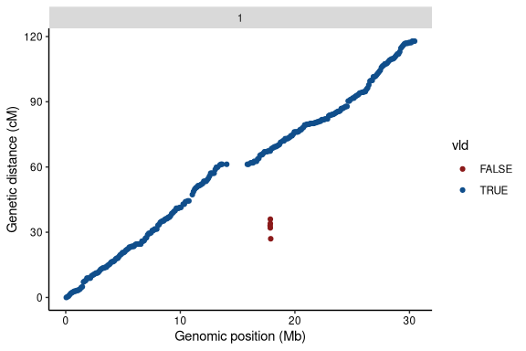

Marey maps of chromosome 1 in *Arabidopsis thaliana*. Invalid markers are shown in red.

```r
phys = c(17855000, 17853000, 17858000, 17840000, 17890000)
gen = c(34, 32, 36, 33, 27)
pos = data.frame(phys = phys, gen = gen)
marey_outliers = mask.marker(marey_outliers, pos)

plot(marey_outliers)
```

```r
rm(marey_outliers)
```

## Correction of scaffold order

The Marey map must be a monotonous increasing function. However, if some regions are not in the same order in the linkage map and the reference genome, they appear as a large segment decreasing with genomic distance. This can be due to biological reasons (structural variants, i.e. inversions) or alignment errors in the genome assembly (the scaffold has been ordered in the wrong direction). It is advised to evaluate the putative cause of this particular error before to correct it. If the cause is not well understood, we advise to discard the entire map. Otherwise, if you think it is an assembly error that can corrected, we provide a function `flip.interval()` to flip the genetic distances on this interval, in order to get them in the same order as the reference genome. Though the error is probably due to the assembly, we made the choice to flip genetic distances in order to conserve the genome annotation.

Below I flipped two intervals, simulating what is happening when some scaffolds of the reference genome and the linkage map are not in the same order. Then I use the same `flip.interval()` function to put them back in the right order.

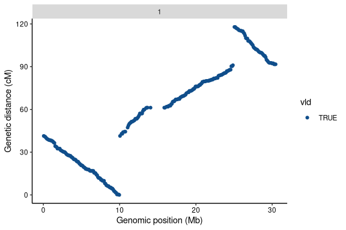

Flipping a genomic interval.

```r
interv = data.frame(start = c(1, 25000000), end = c(10000000, 50000000))
tmp = flip.interval(marey, intervals = interv)
plot(tmp)
```

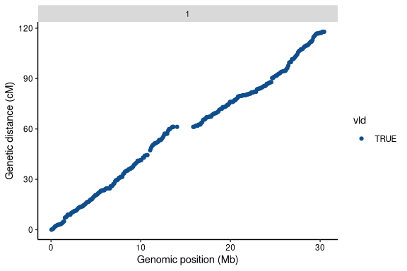

Flipping a genomic interval.

```r
tmp = flip.interval(tmp, intervals = interv)
plot(tmp)
```

You can flip the whole chromosome by specifying a single interval from one to the chromosome length.

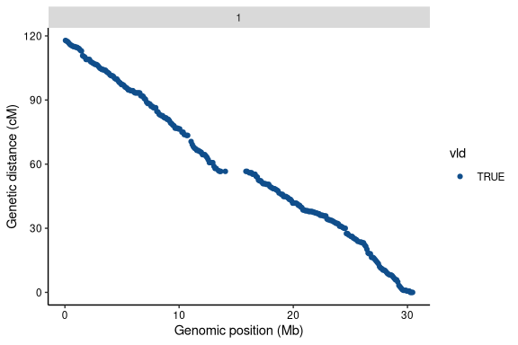

Flipping the entire chromosome

```r
wholechromosome = data.frame(start = c(1), end = c(marey$chromosomeLength))
tmp = flip.interval(marey, intervals = wholechromosome)
plot(tmp)
```

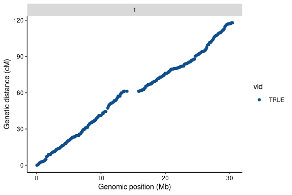

Flipping the entire chromosome

```r
tmp = flip.interval(tmp, intervals = wholechromosome)
plot(tmp)
```

# Estimate a recombination map

Once you have checked (and eventually corrected) the Marey map, you can estimate the recombination rates along the chromosome. Recombination rates are in cM/bp. It is the core feature of the `EasyMareyMap` package. The procedure to estimate the recombination map is done with the `recombination_map()` function which returns a `marey_map` object with an estimated recombination map (`recMap` slot). A description of the interpolation method is available in Brazier and Glémin (Brazier and Glémin 2022). The `recombination_map()` is designed to be user-friendly (only requires a few arguments, functions to plot and summarize), script-friendly to batch analyses (e.g. hundreds of genetic maps), highly automated (automatic fine-tuning of the smoothing parameter) and provide high reproducibility (all parameters and settings are stored in the `marey_map` object and easily accessible).

```r
res = recombination_map(marey, method = "loess")
```

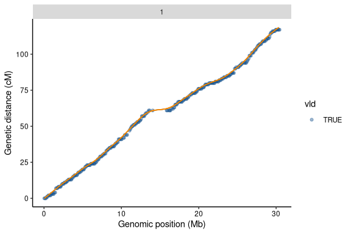

```r
plot(res)
```

```r
head(res$recMap)
```

```
#>                              set map start    end      recRate upperRecRate
#> 1 Arabidopsis_thaliana_Serin2017   1 0e+00  99999          NaN           NA
#> 2 Arabidopsis_thaliana_Serin2017   1 1e+05 199999 4.302678e-06 4.789104e-06
#> 3 Arabidopsis_thaliana_Serin2017   1 2e+05 299999 4.364607e-06 4.877508e-06
#> 4 Arabidopsis_thaliana_Serin2017   1 3e+05 399999 4.387298e-06 4.887265e-06
#> 5 Arabidopsis_thaliana_Serin2017   1 4e+05 499999 4.394586e-06 4.860013e-06
#> 6 Arabidopsis_thaliana_Serin2017   1 5e+05 599999 4.396032e-06 4.842377e-06
#>   lowerRecRate
#> 1           NA
#> 2 3.663111e-06
#> 3 3.764711e-06
#> 4 3.824480e-06
#> 5 3.891871e-06
#> 6 3.960459e-06
```

```r
summary(res)
```

```
#> ===================== Summary of the Marey map ==================
#>  Dataset:  Arabidopsis_thaliana_Serin2017
#>  Chromosome name:  1
#>  Chromosome length (Mb):  30.45
#>  Linkage map length (cM):  117
#>  Number of markers:  275
#>  Markers density (marker/Mb):  9.031199
#>  =========================== Recombination map ===================
#>  Recombination rates (cM/Mb):
#>  Min.   1st Qu.    Median      Mean   3rd Qu.      Max.
#> 1e+06 0.477 3.4 4.08 3.91 4.8 6.24
#> ======================== Interpolation ==========================
#> Interpolation method:  loess
#>  Smoothing parameter:  0.2
#>  Number of windows:  304
#>  Number of bootstraps:  1000
#> ================= Goodness of fit (fitted ~ y) ===================
#>  fitted ~ y R squared:  0.9925402
#>  fitted ~ y adjusted R squared:  0.9925129
#>  fitted ~ y p-value  2.05262e-292
#>  ==================================================================
```

The recombination landscape can be plotted with the `plot_recombination_map()` function. We implemented a bootstrapped procedure (random resampling of markers) to estimate confidence intervals along the genome. It is an important feature to evaluate the quality of the recombination map.

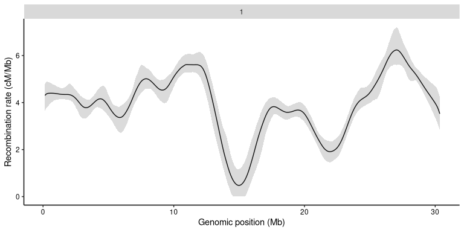

Recombination landscape of *Arabidopsis thaliana*. The gray area is the 95% confidence interval around the mean estimate.

```r
plot_recombination_map(res)
```

# Quality control and map validation

The validity and goodness of fit of statistical interpolation can be assessed with the linear regression of fitted values as a function of observed genetic distances. Once I fitted a loess function, I print the goodness of fit with `summary`.

```r
res_loess = recombination_map(marey, method = "loess", verbose = FALSE)
```

```r
summary(res_loess)
```

```
#> ===================== Summary of the Marey map ==================
#>  Dataset:  Arabidopsis_thaliana_Serin2017
#>  Chromosome name:  1
#>  Chromosome length (Mb):  30.45
#>  Linkage map length (cM):  117
#>  Number of markers:  275
#>  Markers density (marker/Mb):  9.031199
#>  =========================== Recombination map ===================
#>  Recombination rates (cM/Mb):
#>  Min.   1st Qu.    Median      Mean   3rd Qu.      Max.
#> 1e+06 0.477 3.4 4.08 3.91 4.8 6.24
#> ======================== Interpolation ==========================
#> Interpolation method:  loess
#>  Smoothing parameter:  0.2
#>  Number of windows:  304
#>  Number of bootstraps:  1000
#> ================= Goodness of fit (fitted ~ y) ===================
#>  fitted ~ y R squared:  0.9925402
#>  fitted ~ y adjusted R squared:  0.9925129
#>  fitted ~ y p-value  2.05262e-292
#>  ==================================================================
```

It can be used to compare the goodness of fit of different interpolation methods and hyperparameters (i.e. smoothing parameter) I can compare the performance of loess and smooth splines on the same Marey map.

```r
res_spline = recombination_map(marey, method = "spline", verbose = FALSE)
```

```r
summary(res_spline)
```

```
#> ===================== Summary of the Marey map ==================
#>  Dataset:  Arabidopsis_thaliana_Serin2017
#>  Chromosome name:  1
#>  Chromosome length (Mb):  30.45
#>  Linkage map length (cM):  117
#>  Number of markers:  275
#>  Markers density (marker/Mb):  9.031199
#>  =========================== Recombination map ===================
#>  Recombination rates (cM/Mb):
#>  Min.   1st Qu.    Median      Mean   3rd Qu.      Max.
#> 1e+06 1.59 3.14 4.01 3.93 4.91 5.67
#> ======================== Interpolation ==========================
#> Interpolation method:  spline
#>  Smoothing parameter:  0.2
#>  Number of windows:  304
#>  Number of bootstraps:  1000
#> ================= Goodness of fit (fitted ~ y) ===================
#>  fitted ~ y R squared:  0.993156
#>  fitted ~ y adjusted R squared:  0.9931309
#>  fitted ~ y p-value  1.602351e-297
#>  ==================================================================
```

In this case, the two interpolation methods are similarly good. It can be verified by visual comparison.

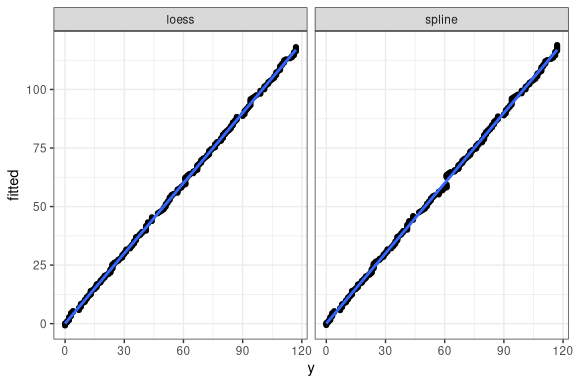

Goodness of fit of two Marey interpolated functions, either with Loess regression or Smooth Splines interpolation. *Arabidopsis thaliana* chromosome 1.

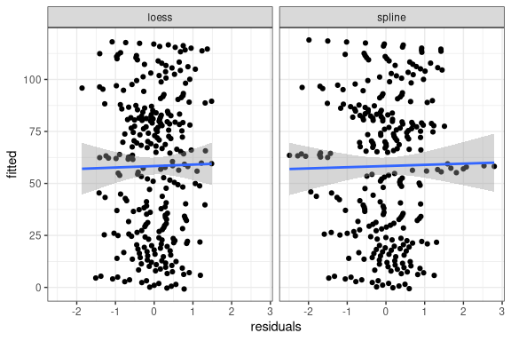

Goodness of fit of two Marey interpolated functions, either with Loess regression or Smooth Splines interpolation. *Arabidopsis thaliana* chromosome 1.

# Changing the physical map

Genetic positions are mapped onto a reference genome (physical positions). Hence manipulating genomic intervals on this physical reference (comparing genomic intervals) or changing the mapping of genetic markers for a new reference map are important features for comparative analyses (e.g. comparing between genomic distances and gene distances as in Brazier and Glémin 2022).

## Estimating recombination rates for a list of genomic intervals

By default, a grid of windows of constant size is mapped along the chromosome to produce the recombination map. But you can also provide a data frame of custom start/end positions to estimate the recombination rate within specific genomic intervals or in a custom set of genomic windows along the genome.

```r
pos = data.frame(start = seq(20000, 40000000, by = 40000),
                 end = seq(20000, 40000000, by = 40000) + 20000)
res = recombination_map(res, method = "loess", windows = pos, verbose = FALSE)
```

This custom positions can represent any genomic feature (e.g. gene, exon) or marker (e.g. SNP) for which you want to estimate the average recombination rate. However keep in mind that interpolation is at a large scale (i.e. does not detect fine scale variations of recombination rates) and close markers can have exactly or very similar values due to the large scale smoothing.

```r
genes = data.frame(chromosome = "4",
                   start = c(60000, 99000, 123000, 267400, 500000),
                   end = c(65000, 99500, 1234000, 267401, 500001))
pos = data.frame(start = genes$start,
                 end = genes$end)
res2 = recombination_map(res, method = "loess", windows = pos, verbose = FALSE)

res2$recMap
```

```
#>                              set map  start     end      recRate upperRecRate
#> 1 Arabidopsis_thaliana_Serin2017   1  60000   65000 4.289153e-06 4.780568e-06
#> 2 Arabidopsis_thaliana_Serin2017   1  99000   99500 4.287976e-06 4.770504e-06
#> 3 Arabidopsis_thaliana_Serin2017   1 123000 1234000 4.306870e-06 4.622715e-06
#> 4 Arabidopsis_thaliana_Serin2017   1 267400  267401 4.375855e-06 4.889229e-06
#> 5 Arabidopsis_thaliana_Serin2017   1 500000  500001 4.386821e-06 4.837693e-06
#>   lowerRecRate
#> 1 3.588709e-06
#> 2 3.608844e-06
#> 3 3.945172e-06
#> 4 3.745853e-06
#> 5 3.894184e-06
```

## Interpolate new genetic positions

You may want to interpolate the genetic distances for a new set of markers. It is possible to interpolate these new positions with the `predict_genetic_map()` function, passing to the `predict` function corresponding to the interpolation method (e.g. `predict.loess` for the `fit.loess` method).

It is recommended to use the same smoothing parameter previously estimated with the automatic calibration procedure.

```
#> ===================== Summary of the Marey map ==================
#>  Dataset:  Arabidopsis_thaliana_Serin2017
#>  Chromosome name:  1
#>  Chromosome length (Mb):  30.45
#>  Linkage map length (cM):  117
#>  Number of markers:  31
#>  Markers density (marker/Mb):  1.018062
#>  =========================== Recombination map ===================
#>  Recombination rates (cM/Mb):
#>  Min.   1st Qu.    Median      Mean   3rd Qu.      Max.
#> 1e+06 0.459 3.41 4.06 3.91 4.8 6.23
#> ======================== Interpolation ==========================
#> Interpolation method:  loess
#>  Smoothing parameter:  0.2
#>  Number of windows:  1000
#>  Number of bootstraps:  1000
#> ================= Goodness of fit (fitted ~ y) ===================
#>  fitted ~ y R squared:  0.9925402
#>  fitted ~ y adjusted R squared:  0.9925129
#>  fitted ~ y p-value  2.05262e-292
#>  ==================================================================
```

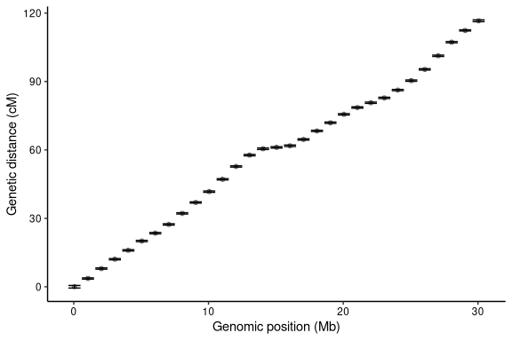

New genetic positions (cM) on chromosome 1, with the confidence interval (+- 1.96*se) of the prediction.

```r
# Re-map on a new set of markers
new = seq(50000, 30450000, by = 1000000)
new_map = predict_genetic_map(res, new)

summary(new_map)
```

# Comparative analysis of recombination landscapes

## Chromosome-wide statistics

To quantitatively describe and compare recombination maps, it is important to estimate summary statistics of the mean and variance of recombination rates. Many summary statistics of heterogeneity in recombination rates can be calculated directly with the `marey_map` object. These statistics, estimated on the whole chromosome, can be used to compare chromosomes in a single species, but also chromosomes between populations or species.

The most simple statistics are the mean, weighted mean (weighted by the windows length), median and the variance.

```r
mean(res)
```

```
#> [1] 3.912888e-06
```

```r
median(res)
```

```
#> [1] 4.075139e-06
```

```r
weighted.mean(res)
```

```
#> [1] 3.912888e-06
```

```r
variance(res)
```

```
#> [1] 1.726989e-12
```

Veller et al. (2019) proposed a rigorous measure of intra-chromosomal genetic shuffling (Veller, Kleckner, and Nowak 2019). The measure depends on the distribution of crossovers along the chromosome and total genome size. The genetic distances must be transformed back to recombinant fractions. The inverse of the mapping function used to calculate genetic distances must be applied.

```r
genome_size = 119050000
veller(res, genome_size = genome_size, mapping_function = "none")
```

```
#> Converting Morgans to recombinant fraction
#> [1] 1.394364e-06
```

```r
veller(res, genome_size = genome_size, mapping_function = "haldane")
```

```
#> Reversed Haldane, converting cM to recombinant fraction
#> [1] 8.453857e-07
```

```r
veller(res, genome_size = genome_size, mapping_function = "kosambi")
```

```
#> Reversed Kosambi, converting cM to recombinant fraction
#> [1] 9.88544e-07
```

```r
peripherybias(res, proportion_periphery = 0.1,  chromosome_arm = "random")
```

```
#> [1] 1.320047
```

```r
peripherybias(res, proportion_periphery = 0.1,  chromosome_arm = "left")
```

```
#> [1] 1.049341
```

```r
peripherybias(res, proportion_periphery = 0.1,  chromosome_arm = "right")
```

```
#> [1] 1.320047
```

```r
peripherybias(res, proportion_periphery = 0.1,  chromosome_arm = "both")
```

```
#> [1] 1.182814
```

The coefficient of variation is a standardized measure of dispersion of a probability distribution or frequency distribution. It is defined as the ratio of the standard deviation divided by the mean.

```r
coefficient_variation(res)
```

```
#> [1] 0.3358516
```

The Gini index is a measure of statistical dispersion intended to represent inequality between measures, here recombination rates. A Gini coefficient of 0 reflects perfect equality, while a Gini coefficient of 1 reflects maximal inequality among values

```r
gini(res)
```

```
#> [1] 0.1852593
```

The Lorenz curve is a graphical representation of the heterogeneity of rates in a dataset, here recombination rates. It plots the ordered distribution of relative recombination rates as a function of their relative physical size. A Lorenz curve always starts at (0,0) and ends at (1,1). The more the curve is close to the diagonal, the less heterogeneous is the distribution of recombination rates.

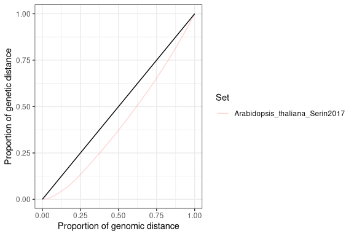

The Lorenz curve of *Arabidopsis thaliana* chromosome 1.

# Comparative analysis of recombination maps

Now it is the time to present the `comparative_marey_map` object. It is a meta-object storing multiple maps (i.e. multiple chromosomes and/or multiple datasets). It allows to perform operations on a list of `mareyMap` maps (e.g. estimating recombination rates), compute summary statistics (e.g. mean, median recombination rates or the gini index) and plot these maps in the same figure in a comparative manner. The `EasyMareyMap` package has also functions to easily manipulate `comparative_marey_map` objects.

As an example I will present recombination maps for female, male and sex-average genetic maps in human.

```r
human = readRDS("../inst/extdata/Homo_sapiens_comparative.Rds")
```

```r
# A short summary of the data stored
summary(human)
```

```
#> ============== Summary of the comparative marey map ==============
#>  Datasets:  Homo sapiens (female) Homo sapiens (male) Homo sapiens (mean) ...
#>  Number of maps:  66
#>  Mean linkage map length (cM):  163.6061
#>  Mean chromosome size (Mb):  129.7833
#>  Mean number of markers:  526.2727
#>  Mean marker density (marker/Mb):  4.157088
#>  ==================================================================
```

```r
# The slots in the comparative_marey_map object
names(human)
```

```
#> [1] "data" "set"  "map"
```

```r
# The class
class(human)
```

```
#> [1] "comparative_marey_map"
```

The recombination maps can be estimated in batch for the whole comparative dataset with the function `comparative_recombination_maps()`.

```r
human = comparative_recombination_maps(human)
```

There are functions to easily get the Marey maps or the recombination maps from a `comparative_marey_map` object.

```r
head(comparative_marey_to_dataframe(human))
```

```
#>                     set           map       mkr    phys gen  vld predict.se
#> 1 Homo sapiens (female) Chromosome 01   D1S2217  837022   0 TRUE         NA
#> 2 Homo sapiens (female) Chromosome 01  WIAF-768  919830   0 TRUE         NA
#> 3 Homo sapiens (female) Chromosome 01 WIAF-3885  989675   0 TRUE         NA
#> 4 Homo sapiens (female) Chromosome 01  WIAF-984 2128800   3 TRUE         NA
#> 5 Homo sapiens (female) Chromosome 01    D1S243 2171436   3 TRUE         NA
#> 6 Homo sapiens (female) Chromosome 01    D1S468 3608114   8 TRUE         NA
```

```r
head(comparative_interpolation_to_dataframe(human))
```

```
#>                     set           map physicalPosition geneticPositioncM
#> 1 Homo sapiens (female) Chromosome 01            50000                 0
#> 2 Homo sapiens (female) Chromosome 01           150000                 0
#> 3 Homo sapiens (female) Chromosome 01           250000                 0
#> 4 Homo sapiens (female) Chromosome 01           350000                 0
#> 5 Homo sapiens (female) Chromosome 01           450000                 0
#> 6 Homo sapiens (female) Chromosome 01           550000                 0
#>   upperGeneticPositioncM lowerGeneticPositioncM
#> 1                      0                      0
#> 2                      0                      0
#> 3                      0                      0
#> 4                      0                      0
#> 5                      0                      0
#> 6                      0                      0
```

```r
head(comparative_recmap_to_dataframe(human))
```

```
#>                     set           map start    end recRate upperRecRate
#> 1 Homo sapiens (female) Chromosome 01 0e+00  99999     NaN           NA
#> 2 Homo sapiens (female) Chromosome 01 1e+05 199999     NaN           NA
#> 3 Homo sapiens (female) Chromosome 01 2e+05 299999     NaN           NA
#> 4 Homo sapiens (female) Chromosome 01 3e+05 399999     NaN           NA
#> 5 Homo sapiens (female) Chromosome 01 4e+05 499999     NaN           NA
#> 6 Homo sapiens (female) Chromosome 01 5e+05 599999     NaN           NA
#>   lowerRecRate
#> 1           NA
#> 2           NA
#> 3           NA
#> 4           NA
#> 5           NA
#> 6           NA
```

## Compare multiple maps mapped on the same chromosome

Different genetic map can be generated in different populations, or between sexes, and mapped on the same reference genome. If the maps share the same set of markers, it is easy to plot them together. Here I compare male, female and sex-averaged recombination maps in *Homo sapiens*, a species with heterochiasmy (i.e. recombination rates are different between sexes).

Let’s work with only two chromosomes and the three datasets to show how to subset maps in a `comparative_marey_map` object. Each map in the `comparative_marey_map` object is a single `marey_map` object. hence you can iterate over each element of `comparative_marey_map$data` to perform custom operations on `marey_map` objects. There is also a function `merge_comparative_marey()` to merge `comparative_marey_map` objects.

```r
# Make a logical vector of maps to keep
subs = (human$map %in% c("Chromosome 02" ,"Chromosome 05"))
human_subset = subset_comparative_marey(human, subset = subs)
```

And now compute three summary statistics on each map.

```r
compute_stats_marey(human_subset, statistics = c("mean", "gini", "peripherybias"))
```

```
#> $set
#> [1] "Homo sapiens (female)" "Homo sapiens (male)"   "Homo sapiens (mean)"
#> [4] "Homo sapiens (female)" "Homo sapiens (male)"   "Homo sapiens (mean)"
#>
#> $map
#> [1] "Chromosome 02" "Chromosome 02" "Chromosome 02" "Chromosome 05"
#> [5] "Chromosome 05" "Chromosome 05"
#>
#> $mean
#> [1] 1.422049e-06 7.770710e-07 1.094594e-06 1.517336e-06 8.400675e-07
#> [6] 1.171480e-06
#>
#> $gini
#> [1] 0.2087580 0.3230733 0.2365540 0.2369744 0.4088750 0.2748154
#>
#> $peripherybias
#> [1] 1.531973 1.924401 1.802875 1.323462 1.985314 1.877357
```

It is easy to compute statistics on a large set of maps (22 chromosomes in three datasets).

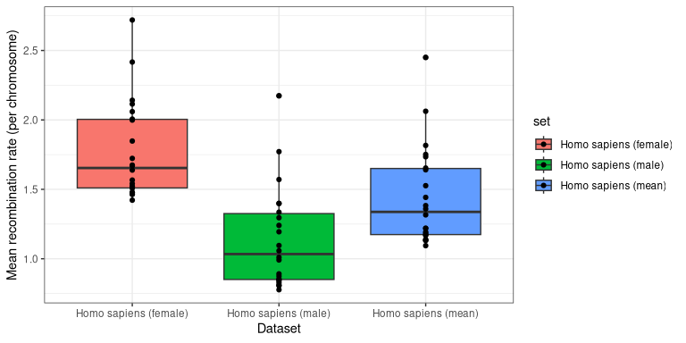

Mean recombinaiton rate per chromosome (cM/Mb) and Gini index for the female, male and sex-averaged genetic maps in human.

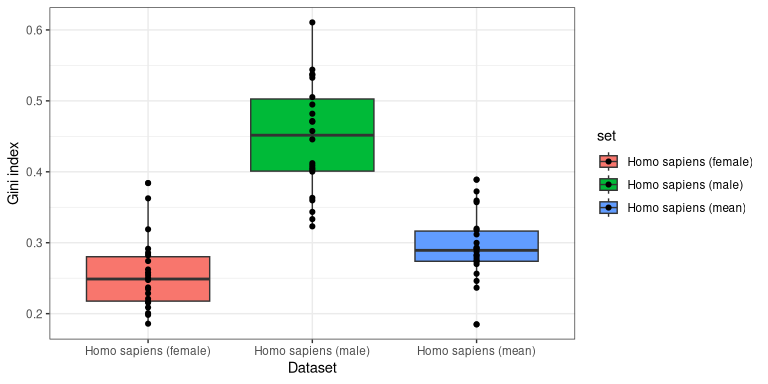

Mean recombinaiton rate per chromosome (cM/Mb) and Gini index for the female, male and sex-averaged genetic maps in human.

You can plot either the Marey maps or the recombination maps with the `plot_comparative_marey()` or the `plot_comparative_recmap()` functions. They return a ggplot object that can be stored or customized. They allow a grouping factor for the plot. Maps can be grouped by `set`, `map` or both (i.e. `set + map`).

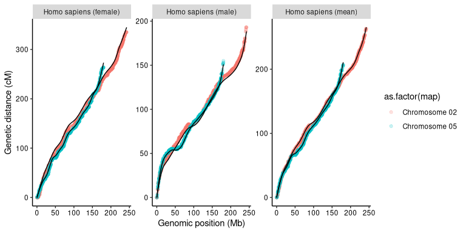

Female, male and sex-averaged Marey maps of *Homo sapiens* chromosomes 2 and 5.

```r
plot_comparative_marey(human_subset, group = "set")
```

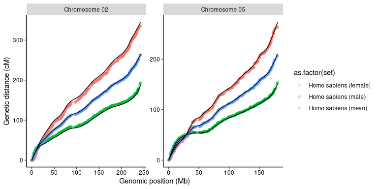

Female, male and sex-averaged Marey maps of *Homo sapiens* chromosomes 2 and 5.

```r
plot_comparative_marey(human_subset, group = "map")
```

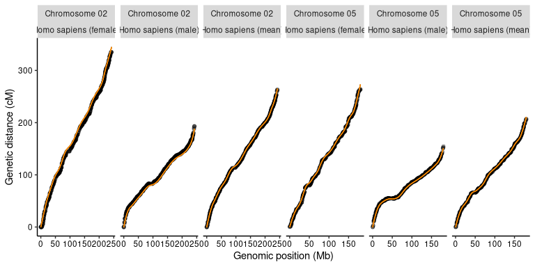

Female, male and sex-averaged Marey maps of *Homo sapiens* chromosomes 2 and 5.

```r
plot_comparative_marey(human_subset, group = "set + map")
```

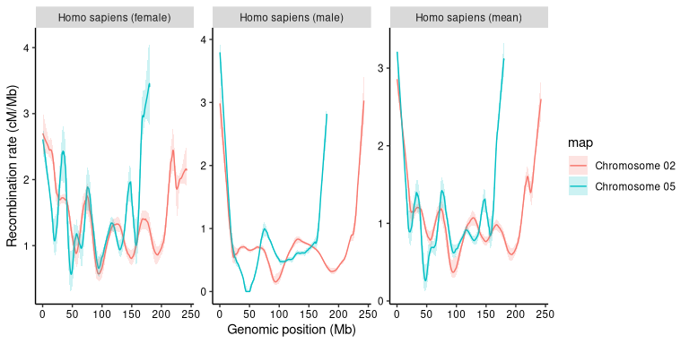

Female, male and sex-averaged recombination landscape of *Homo sapiens* chromosome 2 and 5. The shaded area is the 95% confidence interval around the mean estimate.

```r
plot_comparative_recmap(human_subset, group = "set")
```

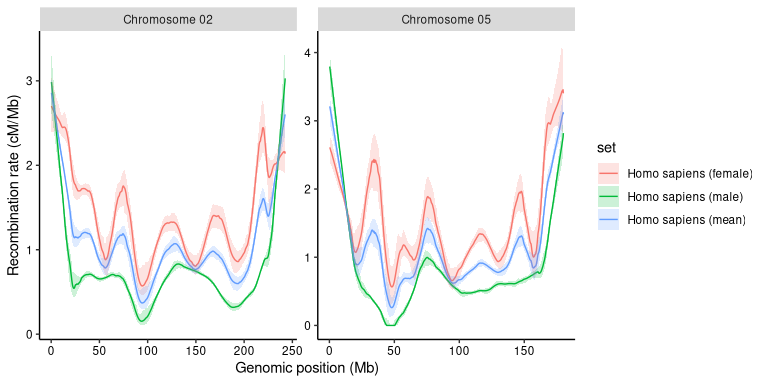

Female, male and sex-averaged recombination landscape of *Homo sapiens* chromosome 2 and 5. The shaded area is the 95% confidence interval around the mean estimate.

```r
plot_comparative_recmap(human_subset, group = "map")
```

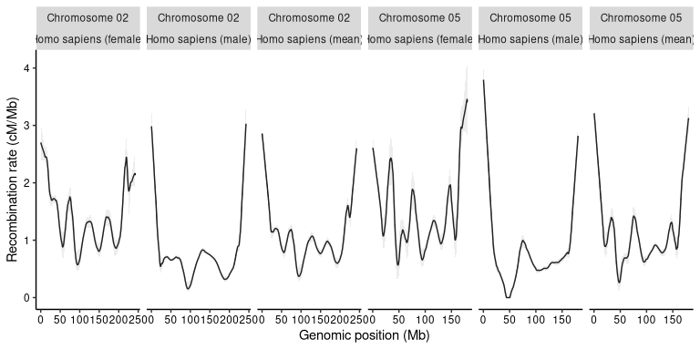

Female, male and sex-averaged recombination landscape of *Homo sapiens* chromosome 2 and 5. The shaded area is the 95% confidence interval around the mean estimate.

```r
plot_comparative_recmap(human_subset, group = "set + map")
```

## Compare between chromosomes/species

```r
maize = readRDS("../inst/extdata/Zea_mays_MaizeGDBConsensus_v4.Rds")
arabidopsis = readRDS("../inst/extdata/Arabidopsis_thaliana.Rds")

summary(maize)
```

```
#> ============== Summary of the comparative marey map ==============
#>  Datasets:  Zea_mays_MaizeGDBConsensus_v4 Zea_mays_MaizeGDBConsensus_v4 Zea_mays_MaizeGDBConsensus_v4 ...
#>  Number of maps:  10
#>  Mean linkage map length (cM):  177.8
#>  Mean chromosome size (Mb):  210.287
#>  Mean number of markers:  629.9
#>  Mean marker density (marker/Mb):  3.006639
#>  ==================================================================
```

```r
summary(arabidopsis)
```

```
#> ============== Summary of the comparative marey map ==============
#>  Datasets:  Arabidopsis_thaliana_Serin2017 Arabidopsis_thaliana_Serin2017 Arabidopsis_thaliana_Serin2017 ...
#>  Number of maps:  5
#>  Mean linkage map length (cM):  93.8
#>  Mean chromosome size (Mb):  23.81
#>  Mean number of markers:  211.8
#>  Mean marker density (marker/Mb):  8.872908
#>  ==================================================================
```

```r
compar = merge_comparative_marey(list(arabidopsis, maize))

summary(compar)
```

```
#> ============== Summary of the comparative marey map ==============
#>  Datasets:  Arabidopsis_thaliana_Serin2017 Arabidopsis_thaliana_Serin2017 Arabidopsis_thaliana_Serin2017 ...
#>  Number of maps:  15
#>  Mean linkage map length (cM):  149.8
#>  Mean chromosome size (Mb):  148.128
#>  Mean number of markers:  490.5333
#>  Mean marker density (marker/Mb):  4.962062
#>  ==================================================================
```

In order to compare maps between two species with contrasted recombination landscapes, for example *Arabidopsis thaliana* and maize, visual methods like the Lorenz curve or expressing physical distances in relative distances cam be very efficient. If you need to compare quantitatively a large number of maps, summary statistics like the Gini index or the periphery-bias ratio are efficient measures of the heterogeneity of recombination rates along the chromosome.

In order to get the data frame instead of the Lorenz plot, you can specify `return.plot = FALSE`. It works also for the `plot.marey_map()` and `plot_recombination` functions.

```r
lorenz(compar)
```

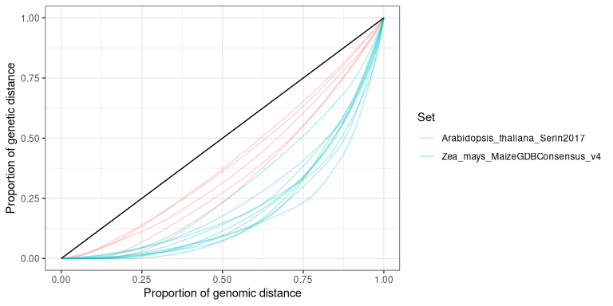

Comparative Lorenz curves between *Arabidopsis thaliana* and maize.

The Broken stick model, as described in Brazier and Glémin (2022), is also an appropriate representation to compare the distribution of recombination rates along the genome across a large set of Marey maps.

```r
brokenstick(compar)
```

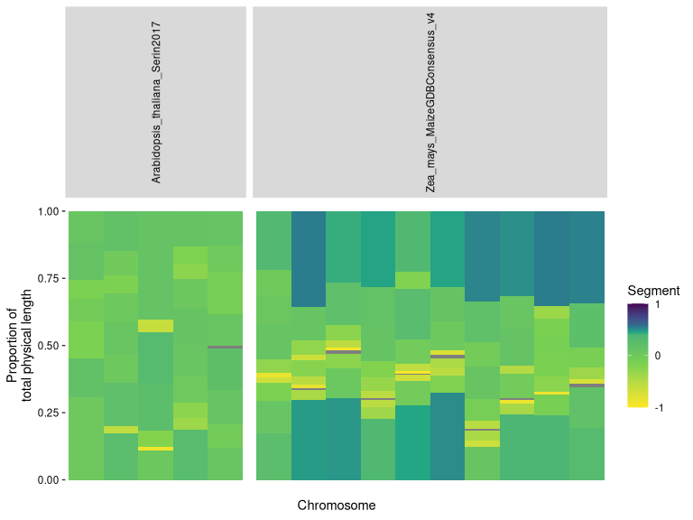

The broken stick model applied to *Arabidopsis thaliana* and maize.

Moreover, to compare between species, it can be interesting to use relative genomic positions and relative recombination rates, instead of absolute ones.

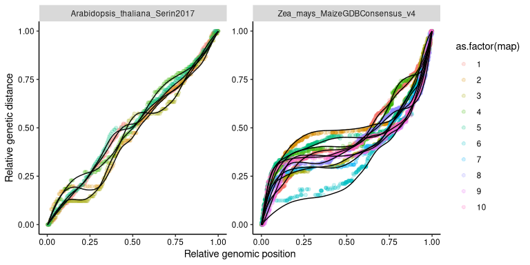

Comparative marey maps between *Arabidopsis* and maize. Genomic distances are relative distances scaled by the total chromosome size. Genetic distances are scaled by the max genetic distance.

```r
plot_comparative_marey(compar, group = 'set', relative_distance_x = T, relative_distance_y = T)
```

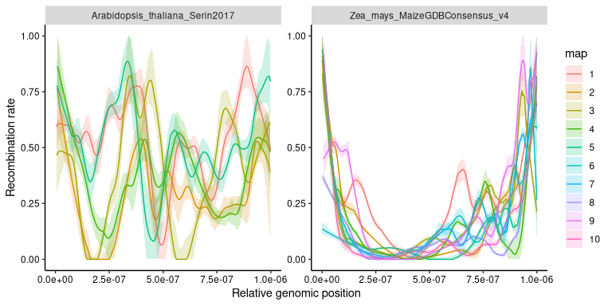

```r
plot_comparative_recmap(compar, group = 'set', relative_distance_x = T, relative_distance_y = T)
```

# References

Brazier, Thomas, and Sylvain Glémin. 2022. “Diversity and Determinants of Recombination Landscapes in Flowering Plants.” Edited by Ian R. Henderson. *PLOS Genetics* 18 (8): e1010141. https://doi.org/10.1371/journal.pgen.1010141.

Muijen, Dennis van, Ram K Basnet, Nathalie NJ Dek, Chris Maliepaard, and Evert W Gutteling. 2017. “Mapfuser: An Integrative Toolbox for Consensus Map Construction and Marey Maps.” *BioRxiv*, 200311.

Rezvoy, C., D. Charif, L. Gueguen, and G. A. B. Marais. 2007. “MareyMap: An R-Based Tool with Graphical Interface for Estimating Recombination Rates.” *Bioinformatics* 23 (16): 2188–89. https://doi.org/10.1093/bioinformatics/btm315.

Serin, Elise A. R., L. B. Snoek, Harm Nijveen, Leo A. J. Willems, Jose M. Jiménez-Gómez, Henk W. M. Hilhorst, and Wilco Ligterink. 2017. “Construction of a High-Density Genetic Map from RNA-Seq Data for an Arabidopsis Bay-0 × Shahdara RIL Population.” *Frontiers in Genetics* 8 (December): 201. https://doi.org/10.3389/fgene.2017.00201.

Veller, Carl, Nancy Kleckner, and Martin A Nowak. 2019. “A Rigorous Measure of Genome-Wide Genetic Shuffling That Takes into Account Crossover Positions and Mendel’s Second Law.” *Proceedings of the National Academy of Sciences* 116 (5): 1659–68.